# Barbell lift

Jiaqi Li

2024-09-24

## Introduction

This project leverages data from accelerometers worn by six people on different parts of their bodies while performing barbell lifts. Each person performed the barbell lift both correctly and incorrectly in five ways. The goal is to build a machine learning model to predict what is the type of the barbell lift. First step is to exploring the data, understanding the feature, and clean up. The two data sets contain 160 columns and the classifier column is “classe”, which indicate 5 types of the movement patterns(A,B,C,D,E).

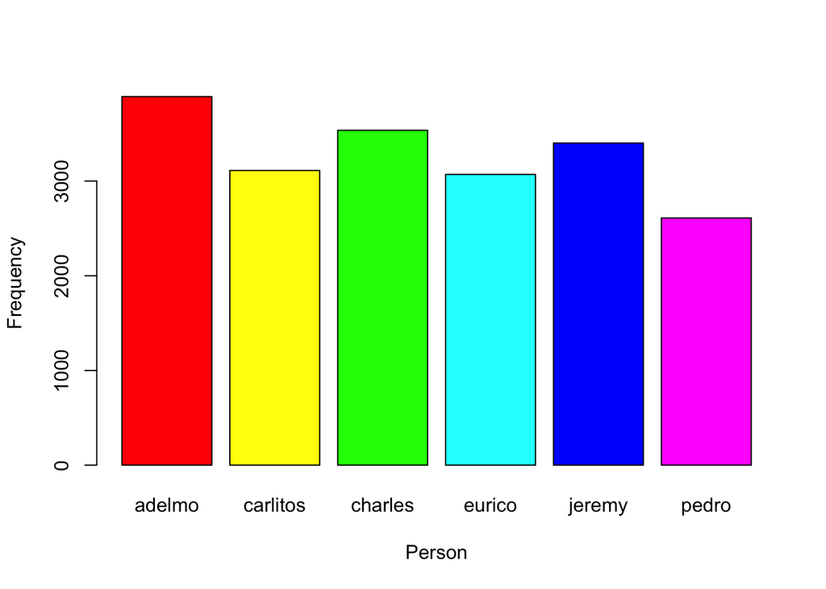

```r
# Load the data
pml_testing <- read.csv("./pml-testing.csv")
pml_training <- read.csv("./pml-training.csv")
# Explore the data
barplot(table(pml_training$user_name),xlab = "Person", ylab = "Frequency",col = rainbow(6), border = "black")
```

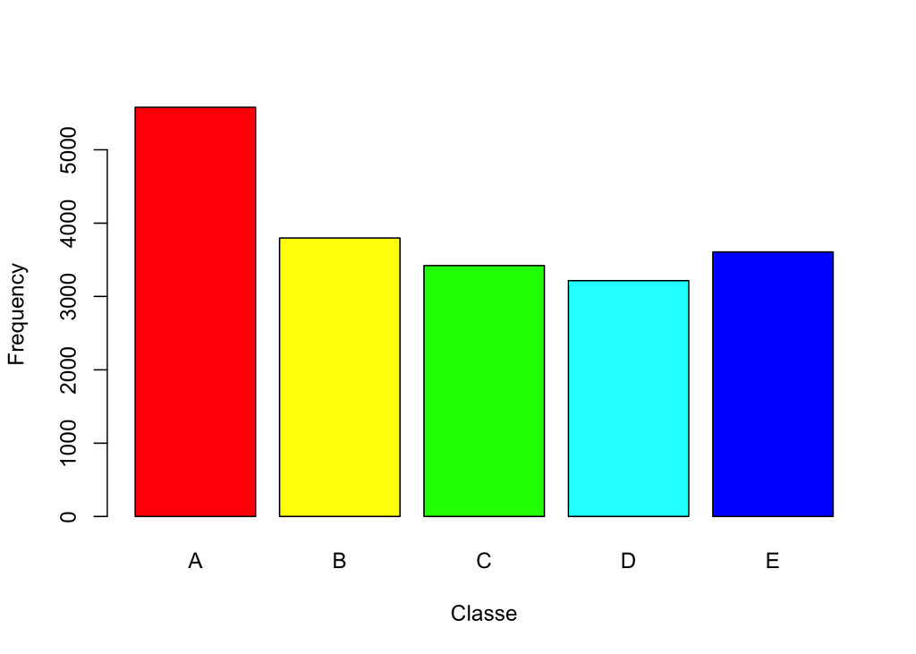

```r
barplot(table(pml_training$classe),xlab = "Classe", ylab = "Frequency",
        col = rainbow(6), border = "black")
```

```r
# Convert the 'classe' to factor
pml_training$classe <- as.factor(pml_training$classe)
```